# Lab 13 - LDA and STM Models

Colin Case, with some code adapted from Rachel Porter

11/30/2022

As we discussed a few weeks ago, text is a rich data source for studying certain political phenomenon among both elites and mass public. In general, as political scientists, there are two general questions we can focus on, as discussed by (Rodriguez and Spirling (2022))[https://doi.org/10.1086/715162]:

1. Estimating political attention or the focus different populations of interest place on different aspects of policy or politics at different times.
2. Characterizing the nature of political conflict or the way in which different populations of interest use different language to discuss similar issues.

In answering the first type of question, topic models have proven extremely useful and will be our focus today.

# Latent-Dirichlet Allocation Model

A few weeks ago, we started by working with how to download, collect, and clean different types of text. Now, we face the problem of actually being able to (1) measure certain characteristics in text and (2) draw inferences from text. To explore what latent topics are in the text, we can fit Latent-Dirichlet Allocation (LDA) models.

What the LDA model is doing, is finding the following parameters using the Bayesian approach:
$$\varphi_{k=1, ... K} \sim Dirichlet_V(\beta) \\
\theta_{d=1, ... M} \sim Dirichlet_K(\alpha) \\
z_{d=1, ... M, w = 1, ... N_d} \sim Categorical_K(\theta_d) \\
w_{d=1, ... M, w=1, ... N_d} \sim Categorical_V(\varphi_{z_{dw}})$$
That is a lot of variables and parameters. Some quantities of interest include:

K - the number of topics, must be manually specified. V - the number of words in the vocabulary (tokens). M - the number of documents in the corpus. $N_{d=1, ... M}$ - number of words in document d. N - total number of words in all documents, or $N= \sum^M_{d=1} N_d$ $\alpha$ - parameter of the Dirichlet prior on the per-document topic distributions $\beta$ - parameter of the Dirichlet prior on the per-topic word distributions $\theta_i$ - topic distribution for document i $\varphi_k$ - word distribution for topic k

So for us, we are mostly interested in $\theta_i$ and $\varphi_k$, or in plain English, what topics can characterize a particular document i, and what words can characterize a particular topic k.

## Text Pre-Processing

Before we get to fitting an LDA model, we first need to complete some text pre-processing steps. The data you will be working with today are campaign positions from candidates websites from 2018 primaries that broadly relate to gender issue positions. We also document level covariates for each candidate’s statement. Let’s take a look and clean this data:

```r
# Clear Environment
rm(list = ls())

# Load Packages
library(quanteda)
library(ggplot2)
library(stm)
library(keyATM)

# Set working Directory
setwd("C:/Users/colin/poli787-fall22/lab13-text2")

# load in data on campaign positions
load("positions_data.RData")

# View Data
head(data)
```

```
## # A tibble: 6 × 8
##      X1 candidate           combo         gender trimmed   inc openseat ss_party
##   <dbl> <chr>               <chr>          <dbl> <chr>   <dbl>    <dbl>    <dbl>
## 1     1 McConnell, Lizzetta Lizzetta McC…      1 I beli…     0        0        0
## 2     2 Kennedy Jr, Robert  Robert Kenne…      0 As a m…     0        0        0
## 3     3 Williams, Audri     Audri Scott …      1 Women …     0        0        0
## 4     4 Isner, Tabitha      Tabitha Isne…      1 <NA>        0        0        0
## 5     5 Hagan, Mallory      Mallory Haga…      1 Elimin…     0        0        0
## 6     6 Neighbors, Rick     Rick Neighbo…      0 <NA>        0        0        0
```

As you can see, we have some statements without issue positions, as well as certain tags we need to remove like we saw a few weeks ago. First, remove these tags as well as any numbers or words not beginning with a letter. Then, remove any observations that don’t have any text in the trimmed field. Finally, create a corpus object, remove stopwords, stem words, as well as remove punctuation.

```r
## remove any tags, unwanted text for analysis
data$trimmed <- gsub("[\n]", "", data$trimmed)
data$trimmed <- gsub("d5", "", data$trimmed)
data$trimmed <- gsub("d0", "", data$trimmed)
data$trimmed <- gsub(" *\\b[[:alpha:]]{1,2}\\b *", " ", data$trimmed)

## remove numbers, any words that do not begin with a letter
data$trimmed <- gsub('[0-9]+', '', data$trimmed)
data$trimmed <- gsub("[^a-zA-Z]", " ", data$trimmed)

## drop any observations with no text
data <- subset(data, !is.na(data$trimmed))

## create corpus object, set text field
issues <- corpus(data, text_field = "trimmed")

## finish preprocessing steps (stop words, stem and remove punctuation)
eng.stopwords <- stopwords('english')
eng.stopwords <- c("congress", eng.stopwords)
iss_dfm <- dfm(issues,
               stem = TRUE,
               remove = eng.stopwords,
               remove_punct = TRUE)

## Examine top features
topfeatures(iss_dfm, 100)
```

```
##      women      right      equal     health     famili       work       care
##       1758        750        631        521        517        488        448
##    support        pay     access       make      woman    protect       plan
##        445        439        413        350        338        336        317
##      fight      abort       must  reproduct     sexual       need  healthcar
##        300        300        285        267        257        246        232
##      decis     servic     provid       paid    violenc        act        law
##        231        228        227        221        213        212        209
## parenthood       also     believ       leav     includ      ensur        can
##        198        197        196        195        189        188        186
##        men     legisl       wage      everi     afford    control       fund
##        179        177        174        174        173        172        171
##      state      choic      choos       issu       educ        one   american
##        165        164        163        158        157        155        155
##     polici     gender       time      peopl  discrimin     harass       like
##        153        152        149        148        142        140        136
##      feder      birth     govern    prevent contracept       life     nation
##        135        135        131        131        128        128        126
##    countri   pregnanc       live    assault       safe       fair        job
##        126        123        120        117        115        115        114
##   workplac        pro       bodi      medic   opportun    continu   children
##        111        111        109        108        107        107        106
##     econom       earn     domest       mani        gap       year      stand
##        104        102         99         99         99         99         99
##    program     effort       abus     matern      allow     person  communiti
##         97         96         96         94         90         88         88
##       rate     victim      insur     employ        end       help     parent
##         88         87         87         86         85         85         84
##       take    without
##         83         82
```

Now that we have our cleaned text, we need to prep the documents for estimating the LDA and STM later in the lab. We also need to make a decision about what our threshold is for dropping certain observations that don’t have a lot of text, as well as dropping infrequent words. For this, we’ll go with a vocab threshold of 5, but keep in mind this really depends on your research question and what the data looks like (the same goes with the pre processing decisions above).

Please note, for this lab and for the sake of time, we are going to be estimating an LDA using the `stm` command without covarariates. It will be similar to an LDA estimated using a package designed specifically for LDA, but in general you should use a command and document preparation specific to LDA if that is your sole focus (for an explanation of the differences, see [Roberts et al. 2014](https://scholar.harvard.edu/files/dtingley/files/topicmodelsopenendedexperiments.pdf)).

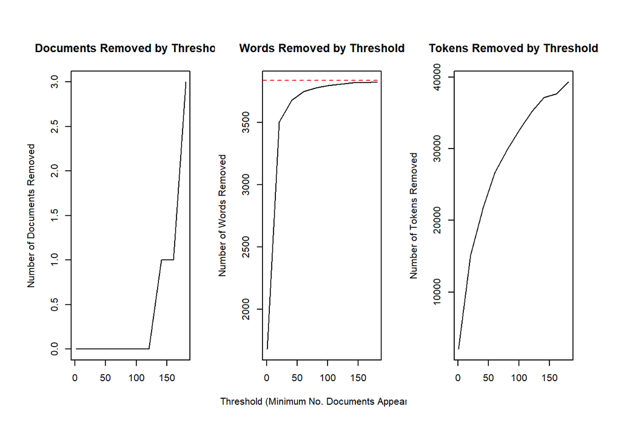

```r
# Convert dfm to stm and lda structure
iss_lda <- convert(iss_dfm, to = 'lda')
iss_stm <- convert(iss_dfm, to = 'stm')


# Plot varying drop thresholds
plotRemoved(iss_stm$documents, lower.thresh=seq(1,200, by=20))
```

```r
# Determining drop threshold
iss_lda <- prepDocuments(iss_lda$documents, iss_lda$vocab,
                         iss_lda$meta, lower.thresh = 5)
```

```
## Removing 2822 of 3835 terms (4975 of 31145 tokens) due to frequency
## Your corpus now has 383 documents, 1013 terms and 26170 tokens.
```

```r
iss_stm <- prepDocuments(iss_stm$documents, iss_stm$vocab,
                         iss_stm$meta, lower.thresh = 5)
```

```
## Removing 2822 of 3835 terms (4975 of 31145 tokens) due to frequency
## Your corpus now has 383 documents, 1013 terms and 26170 tokens.
```

## Number of Topics

This is where our researcher determination becomes very important the choices we make here will have consequences on our results. I would suggest replicating your analysis across multiple topic/drop thresholds to ensure results are not model dependent. Per Grimmer and Stewart (2013), there is no surefire way to choose your number of topics; but there are data-driven approaches for making this determination. The `searchK` function allows for the repeated estimation of stms across different k-topic thresholds. These repeated estimations can then be compared across several diagnostic values to determine K.

To do this, we can use a variety of metrics from searchK (note, this will take a while; it can also be done with `FindTopicsNumber`):

1. Held-out likelihood — the probability of held-out documents given a trained model; goal close to 0 essentially — how good is the model at predicting held out words?
2. Residuals — If the model is correctly specified. If it correctly specified the multinomial likelihood the dispersion of residuals sigma2 should be 1; If > 1, too few topics, cannot account well for topic over-dispersion essentially — is there too much variability in topics?
3. Lower-bound — approximation to the lower bound on the marginal likelihood. You can think of it as the model’s internal measure of fit. Goal is to MAXIMIZE
4. Semantic Coherence — Semantic coherence is maximized when the most probable words in a given topic frequently co-occur together. Goal is to MAXIMIZE.

```r
# Use searchK to find potential number of topics, K, between range of 8 and 12
model_search <- searchK(iss_lda$documents,
                        iss_lda$vocab,
                        K = c(8:12),
                        data = iss_stm$meta,
                        seed = 1996)
```

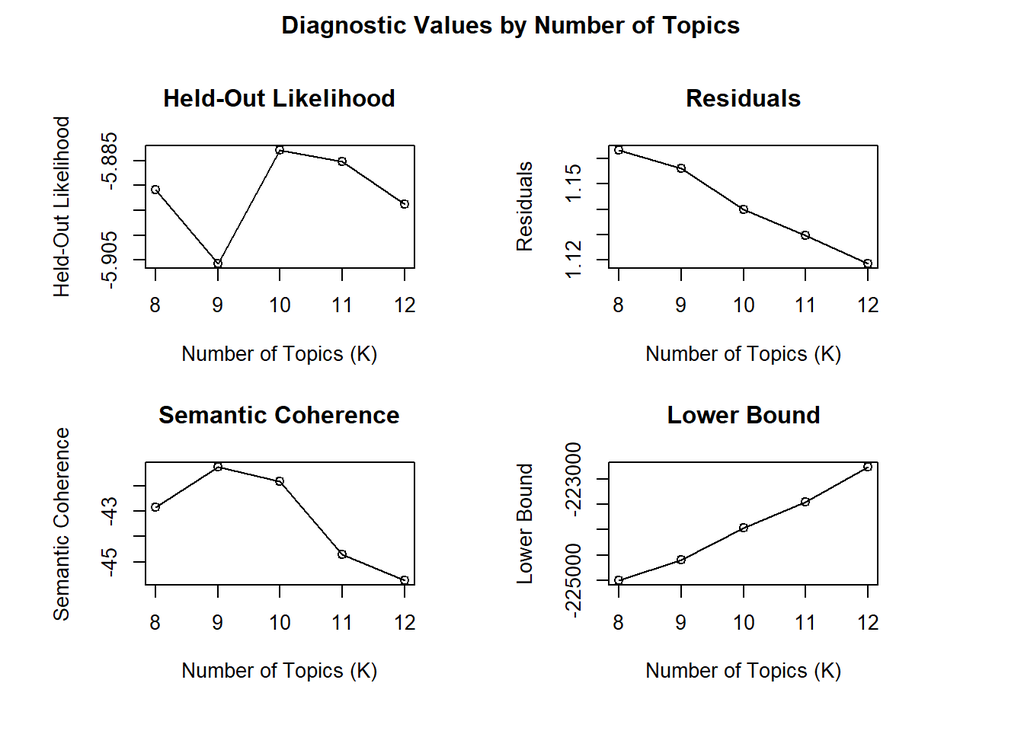

```r
# Plot Results
plot(model_search)
```

## Fitting the LDA

Once you’ve found the best K to use, you can now fit the LDA. Because we are going to spend most of this lab on topic modeling, and this is a more common tool than just running an LDA, we’ll use `stm` without covariates specified.

```r
# Set seed for consistent topic ordering
set.seed(1996)
# Estimate LDA model using STM without covariates
initial_lda <- stm(documents = iss_lda$documents,
                   vocab = iss_lda$vocab,
                   K = 9,
                   data = iss_lda$meta,
                   init.type = "Spectral")
```

What is init.type? The spectral approach utilizes the connection of LDA with non-negative matrix factorization that provides theoretical guarantees that the optimal parameters will be recovered. This overcomes issue of local modes, which may cause differences in results based on changes in starting values (i.e. different seeds set). Spectral initialization should produce more consistent results across multiple runs; setting the seed becomes unnecessary.

Now that we have the model, we can look at the topic prevalence as well as the words that most frequently occur in that topic. By running `labelTopics`, we can get the following:

1. Highest Prob: Words with the highest probability of ocurring in a given topic
2. FREX words: Highest probability words re-weighted by how exclusive they are to a given topic
3. Lift words: Words divided by their overall frequency in other topics
4. Score words: Divide log frequency of a word in a topic by log frequency in other topics

```r
# View Topics and top words
labelTopics(initial_lda, n = 10)
```

```
## Topic 1 Top Words:
##       Highest Prob: women, equal, right, pay, fight, work, support, harass, sexual, reproduct
##       FREX: harass, fight, equal, workplac, stand, champion, pay, movement, assault, fought
##       Lift: champion, ratif, centuri, movement, metoo, leadership, demand, throughout, ago, room
##       Score: champion, equal, harass, fight, gap, movement, women, sexual, pay, reproduct
## Topic 2 Top Words:
##       Highest Prob: famili, women, leav, paid, care, parent, make, work, support, econom
##       FREX: parent, leav, famili, childcar, sick, econom, career, paid, daughter, workforc
##       Lift: sustain, stronger, seat, parent, childcar, sick, list, elder, mandatori, field
##       Score: sustain, famili, leav, childcar, paid, parent, economi, order, next, guarante
## Topic 3 Top Words:
##       Highest Prob: abort, pregnanc, women, educ, pro, life, support, birth, sex, access
##       FREX: abort, pro, pregnanc, sex, unwant, birth, life, educ, roe, reduc
##       Lift: earli, unwant, avoid, rare, perform, abort, term, unplan, debat, although
##       Score: earli, abort, pregnanc, unwant, pro, sex, rare, teen, term, birth
## Topic 4 Top Words:
##       Highest Prob: wage, work, pay, equal, women, job, live, minimum, need, famili
##       FREX: wage, minimum, hour, economi, poverti, hard, job, busi, live, work
##       Lift: war, wage, minimum, inflat, third, hour, breadwinn, concern, circumst, incent
##       Score: war, wage, minimum, economi, gap, hour, inflat, job, poverti, circumst
## Topic 5 Top Words:
##       Highest Prob: right, woman, women, decis, make, bodi, choos, can, govern, issu
##       FREX: bodi, decis, choos, decid, politician, woman, medic, want, govern, never
##       Lift: general, think, decid, bodi, nfamili, faith, trust, hear, regul, tell
##       Score: general, bodi, decis, choos, woman, tell, born, medic, think, right
## Topic 6 Top Words:
##       Highest Prob: equal, right, must, gender, women, discrimin, peopl, protect, law, american
##       FREX: race, orient, disabl, gender, regardless, discrimin, citizen, justic, ident, social
##       Lift: orient, preserv, origin, disabl, nativ, religion, ident, race, lgbtq, ethnic
##       Score: preserv, orient, ident, religion, disabl, race, gender, origin, citizen, equal
## Topic 7 Top Words:
##       Highest Prob: health, women, care, plan, access, servic, parenthood, provid, right, reproduct
##       FREX: parenthood, servic, insur, plan, health, cancer, care, screen, coverag, contracept
##       Lift: weaken, std, prescript, exam, premium, breast, cancer, screen, cervic, naccess
##       Score: weaken, parenthood, cancer, servic, health, screen, care, texa, plan, reproduct
## Topic 8 Top Words:
##       Highest Prob: women, pay, men, earn, equal, act, time, paid, even, countri
##       FREX: paycheck, salari, current, bill, even, interest, cent, earn, averag, minor
##       Lift: region, settlement, complaint, salari, latina, taxpay, listen, interest, middl, true
##       Score: region, salari, paycheck, earn, cent, averag, drive, gap, taxpay, interest
## Topic 9 Top Words:
##       Highest Prob: violenc, women, sexual, domest, act, support, protect, assault, survivor, victim
##       FREX: survivor, violenc, domest, gun, victim, traffick, assault, sponsor, school, campus
##       Lift: relationship, kit, firearm, boyfriend, survivor, stalk, convict, vawa, reauthor, traffick
##       Score: relationship, survivor, violenc, domest, traffick, campus, sponsor, loophol, gun, girl
```

```r
# Save Topic proportions
theta <- data.frame(initial_lda$theta)
```

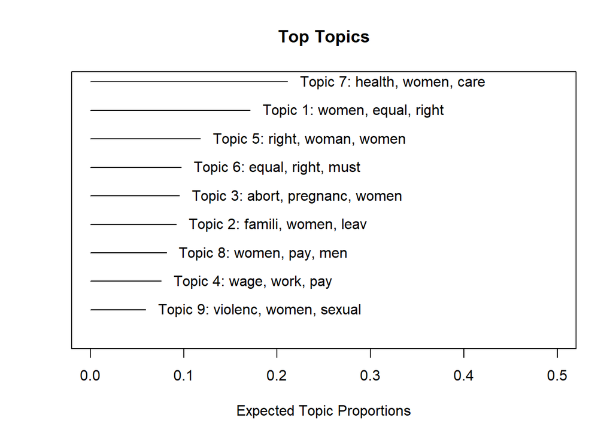

```r
# Plotting overall topic frequency
plot(initial_lda, type = "summary", xlim = c(0, .5))
```

[output not shown]

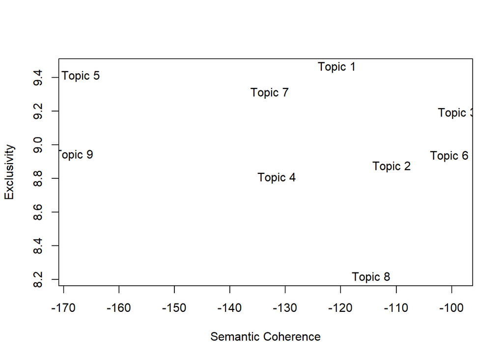

```r
# Plotting overall topic quality
topicQuality(initial_lda,documents=iss_stm$document)
```

[figure not shown]

```r
# Making that plot a little better
labels <- c("Women's Rights", "Family Leave", "Abortion", " Reproductive Healthcare", "Economic Opportunity", "Body Autonomy", "General Healthcare", "Violence against Women", "Equal Pay")

semcoh <- semanticCoherence(initial_lda, documents = iss_stm$documents)
exclusivity <- exclusivity(initial_lda)

semco <- data.frame(labels, semcoh, exclusivity)

ggplot(semco, aes(x = semcoh, y = exclusivity, label=labels)) +
  geom_point() +
  geom_text(aes(label=labels),hjust=-.05, vjust=1) +
  ylim(8,10) +
  xlim(-70,-15) +
  theme_bw() +
  xlab("Semantic Coherence") + ylab("Topic-Word Exclusivity") +
  theme(text = element_text(size=18))
```

# Exercise: Estimating STM

We are now going to go through the same process as above, however this time we will be working with an STM rather than just an LDA model. For this, we are going to test whether or not candidates of different gender focus on different topics when discussing women’s issues.

We already set up the df to be used (`iss_stm`). This time, go through the steps of (1) selecting the number of topics (in the range of 8 to 12) while specifying the prevalence argument as ~ gender + as.factor(ss_party) + openseat (2) estimate the STM using the same argument as above with the prevalence specified (3) label and plot the topics (4) test hypothesis regarding differences in topic prevalence across candidates of different genders.

```r
# Find K using SearchK
model_search <- searchK(iss_stm$documents,
                        iss_stm$vocab, K = c(8:12),
                        prevalence = ~ gender + as.factor(ss_party) + openseat,
                        data = iss_stm$meta, seed = 1996)
```

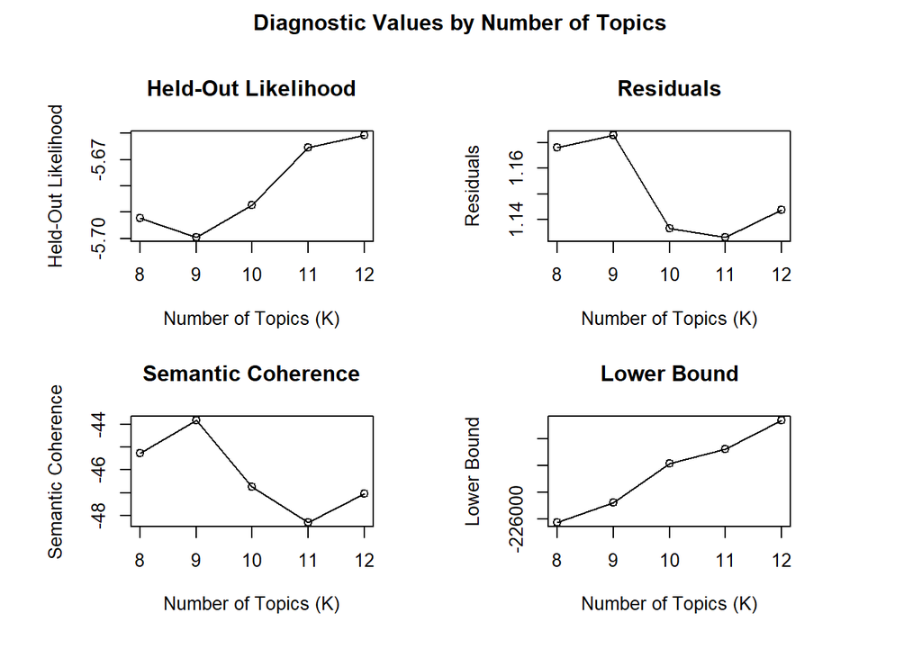

```r
# Plot SearchK results
plot(model_search)
```

```r
# Estimate STM including document covariates
initial_model <- stm(documents = iss_stm$documents,
                     vocab = iss_stm$vocab,
                     K = 9,
                     prevalence = ~ gender + as.factor(ss_party) + openseat,
                     data = iss_stm$meta,
                     init.type = "Spectral")
```

```r
# View Topic top words and general prevalence
labelTopics(initial_model, n = 10)
```

```
## Topic 1 Top Words:
##       Highest Prob: women, equal, pay, right, fight, work, support, harass, sexual, reproduct
##       FREX: fight, harass, equal, workplac, stand, champion, pay, movement, close, throughout
##       Lift: champion, ratif, centuri, movement, metoo, demand, leadership, throughout, ago, room
##       Score: champion, equal, harass, fight, gap, women, pay, movement, sexual, reproduct
## Topic 2 Top Words:
##       Highest Prob: famili, women, leav, paid, care, parent, work, make, econom, support
##       FREX: parent, leav, childcar, famili, sick, econom, career, paid, order, daughter
##       Lift: sustain, stronger, seat, childcar, parent, sick, list, elder, owner, next
##       Score: sustain, famili, leav, childcar, paid, parent, economi, next, order, career
## Topic 3 Top Words:
##       Highest Prob: abort, pregnanc, women, educ, pro, life, support, birth, sex, access
##       FREX: abort, pro, sex, pregnanc, unwant, birth, life, educ, reduc, number
##       Lift: earli, unwant, avoid, perform, abort, rare, term, debat, although, sex
##       Score: earli, abort, pregnanc, unwant, pro, sex, rare, teen, term, birth
## Topic 4 Top Words:
##       Highest Prob: wage, work, pay, equal, women, live, job, minimum, need, famili
##       FREX: wage, minimum, hour, poverti, job, economi, hard, busi, live, gap
##       Lift: war, wage, minimum, inflat, third, breadwinn, hour, concern, circumst, modern
##       Score: war, wage, minimum, economi, gap, hour, inflat, job, poverti, circumst
## Topic 5 Top Words:
##       Highest Prob: right, women, woman, decis, make, bodi, choos, can, govern, issu
##       FREX: bodi, decis, choos, decid, politician, woman, medic, never, govern, want
##       Lift: general, think, decid, faith, nfamili, bodi, trust, hear, difficult, tell
##       Score: general, bodi, decis, choos, tell, woman, born, medic, think, right
## Topic 6 Top Words:
##       Highest Prob: right, equal, must, women, gender, discrimin, peopl, protect, law, american
##       FREX: race, orient, disabl, gender, regardless, discrimin, justic, ident, citizen, social
##       Lift: orient, preserv, origin, disabl, religion, nativ, ident, race, lgbtq, ethnic
##       Score: preserv, orient, ident, religion, disabl, race, gender, origin, equal, citizen
## Topic 7 Top Words:
##       Highest Prob: health, women, care, plan, access, servic, parenthood, right, provid, reproduct
##       FREX: parenthood, servic, insur, plan, health, cancer, care, screen, coverag, contracept
##       Lift: std, weaken, prescript, exam, breast, premium, cancer, screen, cervic, texa
##       Score: weaken, parenthood, cancer, health, servic, screen, care, texa, plan, reproduct
## Topic 8 Top Words:
##       Highest Prob: women, pay, men, earn, equal, act, time, paid, even, countri
##       FREX: paycheck, salari, current, bill, even, interest, cent, minor, group, averag
##       Lift: region, settlement, complaint, salari, latina, taxpay, listen, interest, middl, rank
##       Score: region, salari, paycheck, earn, cent, averag, drive, taxpay, gap, interest
## Topic 9 Top Words:
##       Highest Prob: violenc, women, sexual, domest, act, support, protect, assault, survivor, victim
##       FREX: survivor, violenc, domest, gun, traffick, victim, assault, sponsor, school, campus
##       Lift: relationship, kit, firearm, boyfriend, survivor, stalk, convict, vawa, reauthor, traffick
##       Score: relationship, survivor, violenc, domest, traffick, campus, sponsor, loophol, gun, assault
```

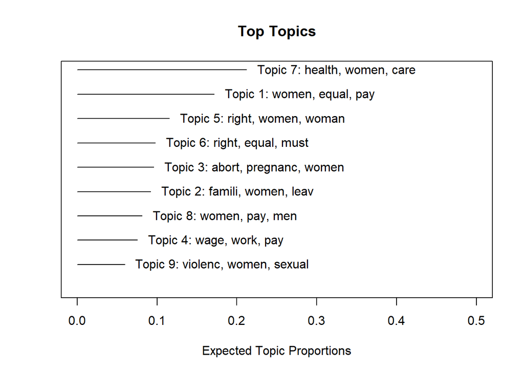

```r
theta <- data.frame(initial_model$theta)

# Plotting overall topic frequency
plot(initial_model, type = "summary", xlim = c(0, .5))
```

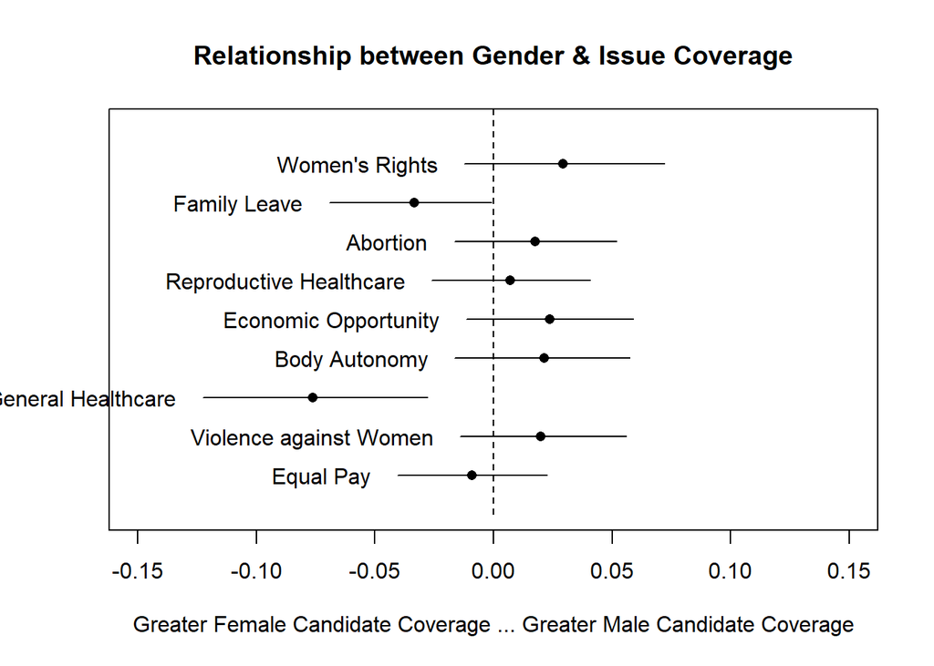

```r
################# TESTING HYPOTHESIS  ###############
# Making Topic Labels Based on Top Words
labels <- c("Women's Rights", "Family Leave", "Abortion", " Reproductive Healthcare", "Economic Opportunity", "Body Autonomy", "General Healthcare", "Violence against Women", "Equal Pay")

prep <- estimateEffect(1:9 ~ gender, initial_model, meta = iss_stm$meta)

plot(prep, covariate="gender", c(1:9),
         model=initial_model, method="difference",
     cov.value1="0", cov.value2="1", ci.level = .90,
     main = "Relationship between Gender & Issue Coverage",
     xlab = "Greater Female Candidate Coverage ... Greater Male Candidate Coverage",
     xlim=c(-.15,.15), labeltype = "custom", custom.labels = labels)
```

As we expected, there are significant differences in how candidates discuss women’s issues!

# Keyword Assisted Topic Models

As we discussed above, labeling topics after the fact is somewhat of an imprecise science. Further, you may approach certain research questions and already have an idea of certain topics that may be important, but those topics don’t appear readily in the results of the STM or LDA. For example, say we want to focus on how candidates of different genders discuss cancer screenings specially when it comes to women’s health. As we can see, topic 7 discusses mammograms but is covering more than just this topic.

This is where keyword assisted topic models come in. KeyATM allows the researcher to specify keywords beforehand that define specific topics. In the simplest terms, this places more weight on these words when defining the topic and has been shown to produce more semantically coherent topics ([See Eshima, Imai and Sasaki 2019](https://arxiv.org/abs/2004.05964) for more details).

For this lab, we are going to focus on creating specific topics surrounding different aspects of women’s healthcare: a general healthcare topic, planned parenthood, birth control, abortion, and cancer.

```r
# Convert dfm to keyATM structure
keyATM_docs <- keyATM_read(texts = iss_dfm)
summary(keyATM_docs)
```

```
## keyATM_docs object of: 383 documents.
## Length of documents:
##   Avg: 120.008
##   Min: 3
##   Max: 2679
##    SD: 175.531
## Number of unique words: 4600
```

```r
# recalling top words across documents
topfeatures(iss_dfm, n = 100)
```

```
##      women      right      equal     health     famili       work       care
##       1758        750        631        521        517        488        448
##    support        pay     access       make      woman    protect       plan
##        445        439        413        350        338        336        317
##      fight      abort       must  reproduct     sexual       need  healthcar
##        300        300        285        267        257        246        232
##      decis     servic     provid       paid    violenc        act        law
##        231        228        227        221        213        212        209
## parenthood       also     believ       leav     includ      ensur        can
##        198        197        196        195        189        188        186
##        men     legisl       wage      everi     afford    control       fund
##        179        177        174        174        173        172        171
##      state      choic      choos       issu       educ        one   american
##        165        164        163        158        157        155        155
##     polici     gender       time      peopl  discrimin     harass       like
##        153        152        149        148        142        140        136
##      feder      birth     govern    prevent contracept       life     nation
##        135        135        131        131        128        128        126
##    countri   pregnanc       live    assault       safe       fair        job
##        126        123        120        117        115        115        114
##   workplac        pro       bodi      medic   opportun    continu   children
##        111        111        109        108        107        107        106
##     econom       earn     domest       mani        gap       year      stand
##        104        102         99         99         99         99         99
##    program     effort       abus     matern      allow     person  communiti
##         97         96         96         94         90         88         88
##       rate     victim      insur     employ        end       help     parent
##         88         87         87         86         85         85         84
##       take    without
##         83         82
```

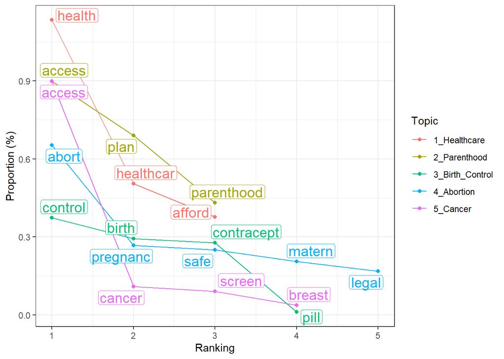

```r
# specify keywords for topic modeling
keywords <- list(Healthcare             = c("healthcar", "afford", "health"),
                 Parenthood             = c("plan", "parenthood", "access"),
                 Birth_Control          = c("contracept", "birth", "control", "pill"),
                 Abortion               = c("abort", "safe", "legal", "pregnanc", "matern"),
                 Cancer                 = c("breast", "cancer", "screen", "access"))

# visualize keyword occurrence across documents; determine strength of keywords
visualize_keywords(docs = keyATM_docs, keywords = keywords, label_size = 5)
```

```r
# specify covariate data for modeling
covariate_data = data[,c("gender", "openseat", "ss_party")]
covariate_data$ss_party <- as.factor(covariate_data$ss_party)

# specifying topic model
out <- keyATM(docs              = keyATM_docs,
              no_keyword_topics = 5,
              keywords          = keywords,
              model             = "covariates",
              model_settings    = list(covariates_data = covariate_data,
                                       covariates_formula = ~ gender + openseat + ss_party),
              options           = list(seed = 250, iterations = 1000))

# assessing topic content
top_words(out, n=15)
```

```
##     1_Healthcare   2_Parenthood 3_Birth_Control   4_Abortion   5_Cancer
## 1          women          women           right    abort [✓]    violenc
## 2     health [✓]       plan [✓]     control [✓] pregnanc [✓]     sexual
## 3         famili parenthood [✓]            issu     safe [✓]     domest
## 4           care          right             can         educ        act
## 5           make         servic       birth [✓]   matern [✓]    assault
## 6     access [2]         legisl             one          law access [✓]
## 7           work          state  contracept [✓]         rate     victim
## 8          woman        continu            life    legal [✓]    program
## 9      reproduct          stand            bodi        reduc    support
## 10       support          trump           peopl          pro       girl
## 11          need           fund           choic          sex screen [✓]
## 12 healthcar [✓]     republican          person        decis      feder
## 13          must           back          govern      support       fund
## 14        provid       restrict          mother        child       like
```

[output cut: 17 more lines]

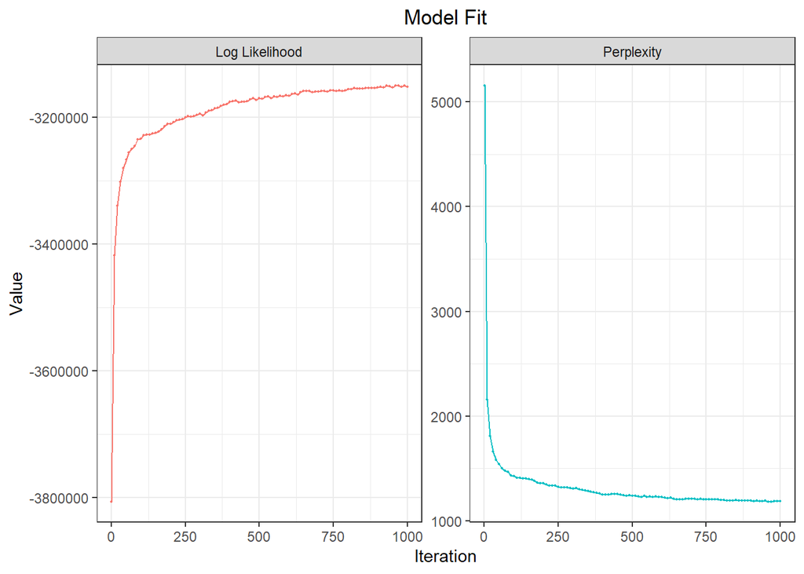

```r
# assessing model fit
plot_modelfit(out)
```

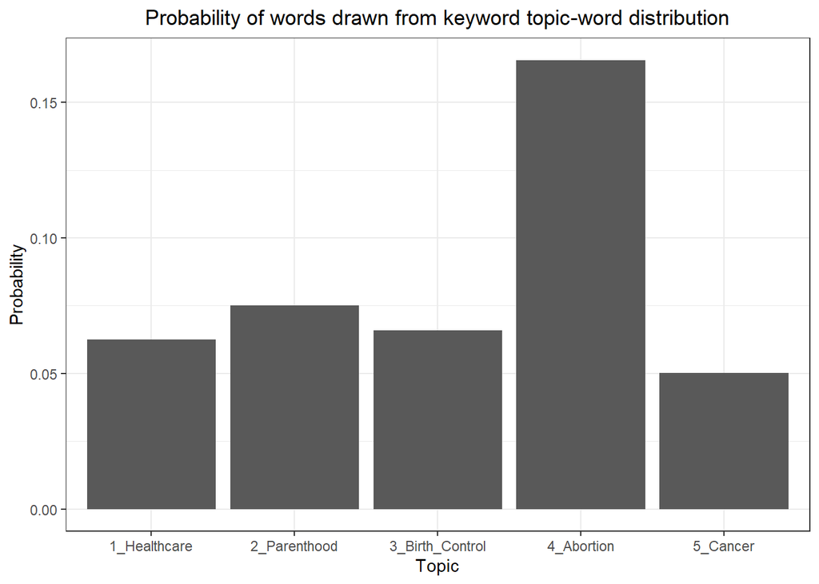

```r
plot_pi(out)
```

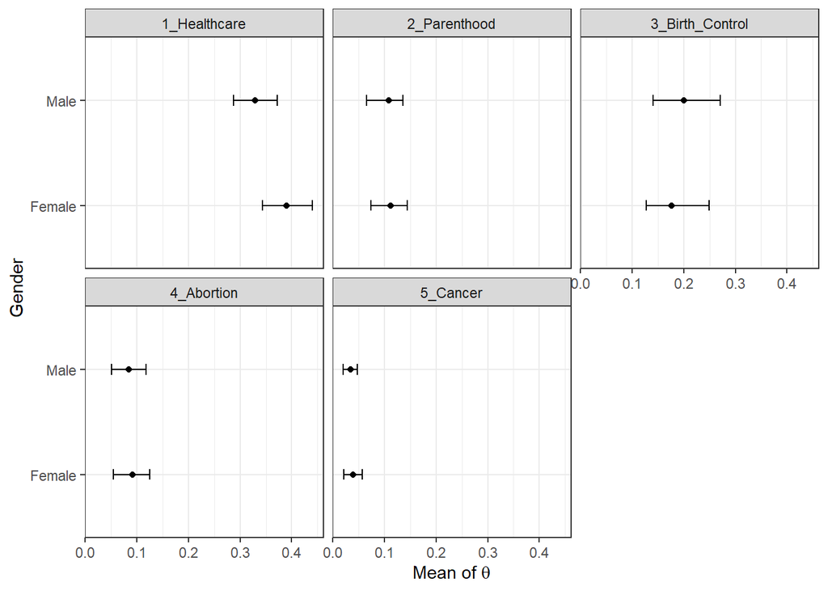

```r
# examining our hypothesis
strata_topic <- by_strata_DocTopic(out, by_var = "gender",
                                   labels = c("Male", "Female"))
fig_doctopic <- plot(strata_topic, var_name = "Gender", show_topic = c(1:5))
fig_doctopic
```